# Predicting correctness of a weight lifting exercise from body sensor data

Carsten Behring

Tuesday, October 21, 2014

# Sope of Analysis

The scope of this analyses is to build a model with machine learning in order to predict if a certain weigh-lifting exercises (10 repetitions of the Unilateral Dumbbell Biceps Curl) is correctly executed or not. The predictors are measurements of several sensors placed at the human body during the exercise.

For details, please see the original paper here: http://groupware.les.inf.puc-rio.br/public/papers/2013.Velloso.QAR-WLE.pdf

# Summary

By using sensor data which measures the 3D movements of the body at 4 specific body locations (arm, forearm, dumbbell, belt) it is possible to predict if a exercise was done correctly or not (and which mistake has been made) with a high degree of accuracy.

Using the random-Forest algorithm we get an estimate for the error rate of 0.8 %.

# Data aquisition

The raw data is accessible here http://groupware.les.inf.puc-rio.br/har.

The data set contains the following information:

- “classe” : the result, if the exercise was executed correctly or not. It is encoded as:
  - A : correctly according to the specification
  - B : throwing the elbows to the front
  - C : lifting the dumbbell only halfway
  - D : lowering the dumbbell only halfway
  - E : throwing the hips to the front
- several values about the time of the measurement
- raw sensor data
- summary statistics of sensor data per time window

Read more here:

- Website : http://groupware.les.inf.puc-rio.br/har#ixzz3H3Otr2Fy
- Paper : http://groupware.les.inf.puc-rio.br/public/papers/2013.Velloso.QAR-WLE.pdf

# Feature selection

I decided to use only the predictors with the raw sensor measurements and exclude therefore all others parameters. Most of the excluded variables are summary statistics of the raw data.

As they are summaries per time window, they should not add anything substantial new to the model.

So the final feature set used for training is this:

```r
predictors_to_keep <- c("classe",grep("_x$|_y$|_z$",names(training),value = T))
predictors_to_keep
```

```
##  [1] "classe"            "gyros_belt_x"      "gyros_belt_y"
##  [4] "gyros_belt_z"      "accel_belt_x"      "accel_belt_y"
##  [7] "accel_belt_z"      "magnet_belt_x"     "magnet_belt_y"
## [10] "magnet_belt_z"     "gyros_arm_x"       "gyros_arm_y"
## [13] "gyros_arm_z"       "accel_arm_x"       "accel_arm_y"
## [16] "accel_arm_z"       "magnet_arm_x"      "magnet_arm_y"
## [19] "magnet_arm_z"      "gyros_dumbbell_x"  "gyros_dumbbell_y"
## [22] "gyros_dumbbell_z"  "accel_dumbbell_x"  "accel_dumbbell_y"
## [25] "accel_dumbbell_z"  "magnet_dumbbell_x" "magnet_dumbbell_y"
## [28] "magnet_dumbbell_z" "gyros_forearm_x"   "gyros_forearm_y"
## [31] "gyros_forearm_z"   "accel_forearm_x"   "accel_forearm_y"
## [34] "accel_forearm_z"   "magnet_forearm_x"  "magnet_forearm_y"
## [37] "magnet_forearm_z"
```

I fitted as well an other model which included the timing information; so when exactly a certain measurement was done and to which window it belongs. But those did not change the accuracy of the model, so I did not include them in the final model.

It seems that the individual body part movements “at any moment in time” are able to predict precisely, if a ongoing weight lifting exercise gets done correctly or not. Looking at summary information per window of time, does not change the accuracy.

# Training of model

We train then a model which is using the “classe” variable as the response to predict. This variables encodes the outcome of the exercise with:

- correct (A)
- a certain error made (B,C,D,E)

```r
training <- training[,predictors_to_keep]
fit <- randomForest(classe ~ .,data=training)
fit
```

```
##
## Call:
##  randomForest(formula = classe ~ ., data = training)
##                Type of random forest: classification
##                      Number of trees: 500
## No. of variables tried at each split: 6
##
##         OOB estimate of  error rate: 0.85%
## Confusion matrix:
##      A    B    C    D    E class.error
## A 5572    2    1    4    1 0.001433692
## B   26 3752   18    1    0 0.011851462
## C    1   26 3394    1    0 0.008182350
## D    4    0   68 3141    3 0.023320896
## E    0    1    2    7 3597 0.002772387
```

We see in the confusion matrix of the training process, that the estimated accuracy of the model for out-of-sample predictions values is about 99.2 % overall. An explicit cross-validation is not needed by using the random forest algorithm, as it is part of the algorithm already.

So we expect that the model predicts 99.2 % of the cases correctly.

# Importance of variables

The importance plot

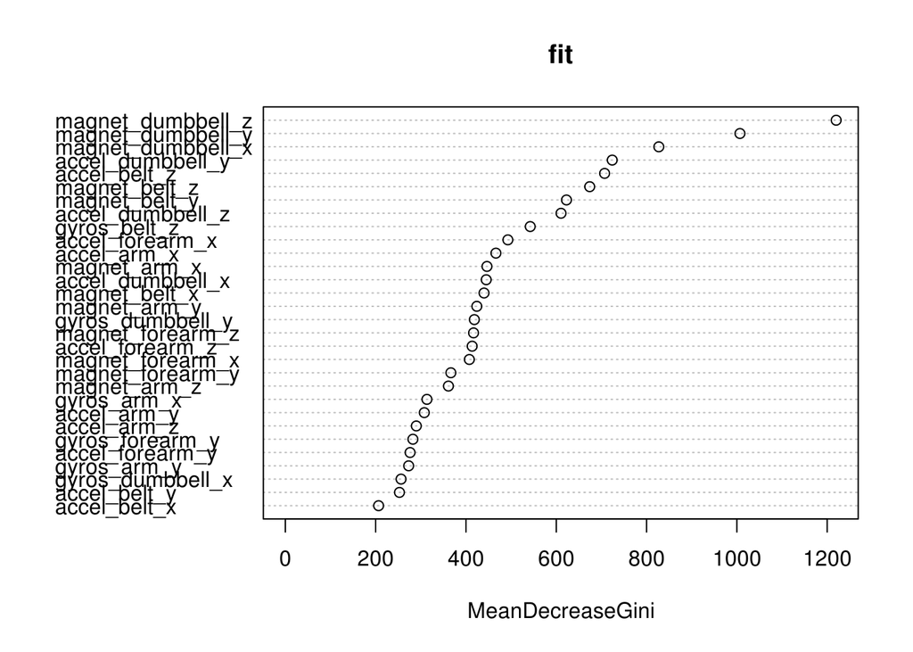

of the model variables shows that the magnetometer measurements of the dumbbell are the most influential variables in the training data. The movements of arm and forearm give little importance for detecting the correct movements of the Biceps Curl.

# Prediction

The prediction of the “classe” from the 20 cases of the test data set is as following:

```r
testing <- testing[,predictors_to_keep[-1]]
prediction <- predict(fit,newdata=testing)
prediction
```

```
##  1  2  3  4  5  6  7  8  9 10 11 12 13 14 15 16 17 18 19 20
##  B  A  B  A  A  E  D  B  A  A  B  C  B  A  E  E  A  B  B  B
## Levels: A B C D E
```

We would expect to have no error in predicting the 20 cases from the exercise, which turned out to be correct.